# AMMS IBS & IBD Practical

# Practical Goals

By the end of this practical, you should understand the following concepts:

- IBS is straightforward to calculate but can produce biased estimates of relatedness (*i.e.* does not necessarily reflect ancestry and is affected by population level allele frequencies)
- IBD captures recent relatedness, useful for determining transmission events, transmission intensity, importation, and corridors of gene flow
- Therefore, IBS/IBD can measure connectivity on spatial-temporal scales relevant to malaria control and elimination efforts
- IBD should decay with distance (isolation by distance) and time; when it does not, interesting things may be happening

# 2 Importing Data

Here, we will use the `vcfR` [package](https://knausb.github.io/vcfR_documentation/) to read in our variant call file (VCF) that contains fifty biallelic SNPs for our twenty-five individuals across our five populations (A, B, C, D, E; *individuals named* A1-5, B1-5, …).

Using the skills that you acquired yesterday, read in the VCF from our data folder that you downloaded from Github: `data/simulated_ibd.vcf.gz`. If you are having trouble locating the file on your computer, please type `file.choose` into your console for an interactive option to locate the file. Name the object (the vcf file you are reading in) “vcf” for simplicity.

```r
# participants DO NOT need to include the quiet bit
vcf <- quiet(vcfR::read.vcfR("data/simulated_ibd.vcf.gz"))
```

## 2.1 Initial QC

As is always good practice, we can check our VCF for missing data and confirm it has the number of SNPs and samples that we expect. Explore the details and inner-workings of our new VCF to get a sense if it is trustworthy (*i.e.* does the data look reasonable? Is there anything strange in the INFO column?). In addition, use the `extract.gt` function from the vcfR package to pull out the allele depth (first record) for your new VCF. Now plot that allele depth as an initial data exploration using the `heatmap.bp` function from the `vcfR` package.

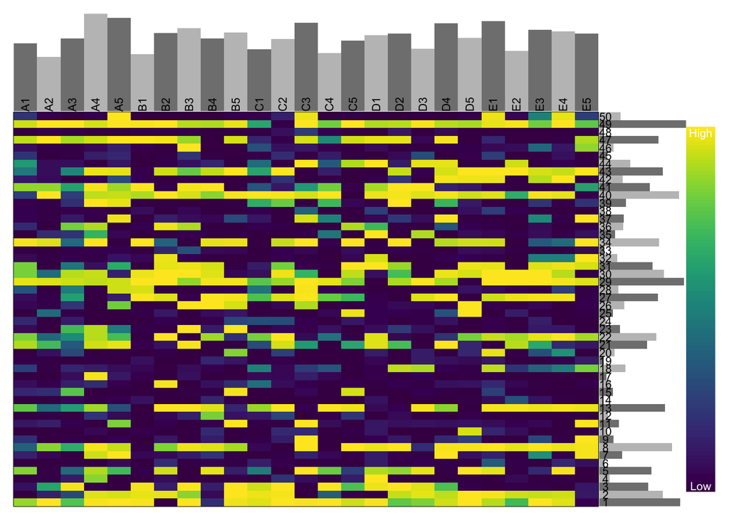

```r
ad <- vcfR::extract.gt(vcf, element = "AD", as.numeric = T)
vcfR::heatmap.bp(ad)
```

**Conceptual Question:** Is above plot consistent w/ a high quality VCF?  
**Answer:** While it does look quality, there are several features that would make you question if it was real data:  
- All of the REF/ALT basepair allele calls are “N” missing  
- All of the loci allele depths are 100  
- The QUALTIY column is all the same  
This data was simulated, and thus, lacks many of the “real world” appearances of a VCF generated from real sequencing data. It is always valuable to manually look at the VCF (or portions of it is large) to determine it’s validity before starting analyses (for those interested or with time at the end of the tutorial, please see the *Advanced Section* for command line manipulations of the VCF)!

## 2.2 Exploring Hets

Here, we will explore the number of heteerzygous genotype calls we have per sample in our VCF.

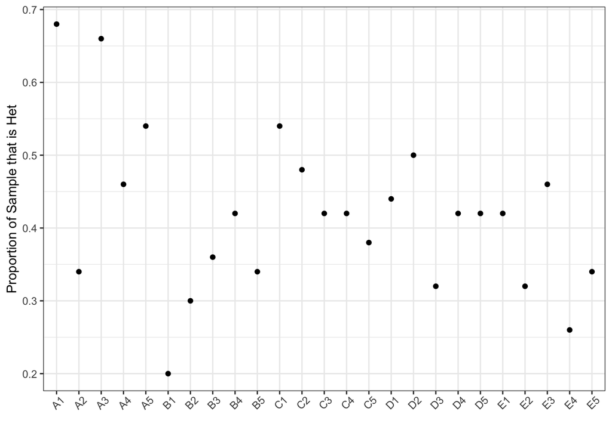

```r
# extract and tidy
gt <- vcfR::extract.gt(vcf, element = "GT")
gt <- dplyr::bind_cols("chrom" = vcfR::getCHROM(vcf), "pos" = vcfR::getPOS(vcf), gt)
gt %>%
  tibble::as_tibble() %>%
  tidyr::pivot_longer(., cols = !c("chrom", "pos")) %>%
  dplyr::mutate(ishet = dplyr::case_when(value == "0/0" ~ F,
                                         value == "0/1" ~ T,
                                         value == "1/1" ~ F)) %>%
  dplyr::group_by(name) %>%
  dplyr::summarise(
    propHet = mean(ishet)) %>%
  ggplot() +
  geom_point(aes(x = name, y = propHet)) +
  ylab("Proportion of Sample that is Het") +
  xlab("") +
  theme_bw() +
  theme(axis.text.x = element_text(angle = 45, vjust = 0.75, hjust = 0.5))
```

**Conceptual Question:** Do you recognize any pattern in heterozygote calls with respect to demes? How does this relate to the polyclonality lesson yesterday?  
**Answer:** Demes with higher transmission intensity have more heterozygote calls

# 3 Intuition

## 3.1 Visualizing Recombination

One approach of conceptualizing recombination is as a “stick breaking” process. For example, you can imagine that you have two sticks that are identical (*i.e.* twins, or clonal infections). In each new generation, you have to randomly break your stick at some point along its length. You then take your pieces of stick and flip a coin to determine if it will remain the same (“original”) or inherit genetic material (“new”). Use the `view_recombo` (loaded from `R/utils.R`) to appreciate that as time increase, recombination block length decreases.

For example, you could run the function with the following generational times.

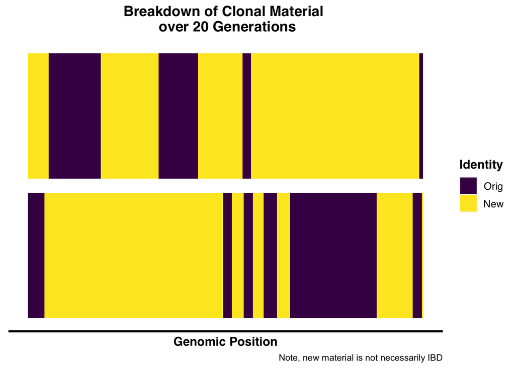

```r
view_recombo(generations_apart = 0)
view_recombo(generations_apart = 1)
view_recombo(generations_apart = 2)
view_recombo(generations_apart = 3)
view_recombo(generations_apart = 5)
view_recombo(generations_apart = 10)
view_recombo(generations_apart = 20)
```

**Conceptual Question:** How does the amount of “clonal” genetic material change, or amount of the genome that is identical, change between the paired samples as we increase the number of generations that separates them?  
**Answer:** Decreases

# 4 Calculations

### 4.0.1 Internal Data Manipulation

Here, we are going to convert our *vcf* object that we read in with the `vcfR` package to a *mip* object in order to later use the [`MIPAnalyzer` Package](https://github.com/mrc-ide/MIPanalyzer/tree/master/R) and the maximum likelihood estimator of IBD from [Verity et al. 2020](https://pubmed.ncbi.nlm.nih.gov/32355199/). This is purely for convenience and is not changing the underlying data in the vcf.

```r
mipvcf <- MIPanalyzer::vcf2mipanalyzer_biallelic(vcfR = vcf)
```

## 4.1 Identity by State

**Challenge:** Pick two samples from your VCF and write your own function to calculate IBS between the pair.  
**Example Answer:** (unfold code).

```r
# pick two samples
simpleIBS <- function(vcfRobj, smpl1name, smpl2name) {
  # extract GT information from vcf
  gt <- vcfR::extract.gt(vcfRobj, element = "GT")
  # subset to our samples, these are now vectors
  smpl1 <- gt[,smpl1name]
  smpl2 <- gt[,smpl2name]
  # evaluate if each element in vector is the same or different = Boolean result
  # take mean to get a proportion (binomial mean)
  ibsprop <- mean(smpl1 == smpl2)
  return(ibsprop)
}

simpleIBS(vcfRobj = vcf, smpl1name = "A1", smpl2name = "D1")
```

### 4.1.1 Run Package IBS

Next, we will use the IBS calculator from the `MIPAnalyzer` R package to calculate pairwise IBS for all combinations of samples in our simulated data. Please see the code below for ease of running the algorithm.

```r
# get IBS
ibs <- MIPanalyzer::get_IBS_distance(x = mipvcf,
                                     ignore_het = FALSE,
                                     report_progress = FALSE)
```

#### 4.1.1.1 Tidy Results

The function returns the data in a “wide” format or a [distance matrix](https://en.wikipedia.org/wiki/Distance_matrix). While this a perfectly acceptable format, it is not considered “tidy”. We will perform some data munging below to transform the data into “long” format and make it more “tidy” for ease of use and plotting.

```r
# tidy result
colnames(ibs) <- rownames(ibs) <- colnames(vcf@gt)[2:ncol(vcf@gt)]

ibs_long <- broom::tidy(as.dist(ibs)) %>%
  magrittr::set_colnames(c("p1", "p2", "ibsdist"))
```

#### 4.1.1.2 Explore Results

It is always good practice to explore our results. Let’s make a boxplot to explore the distribution of our calculated IBS results.

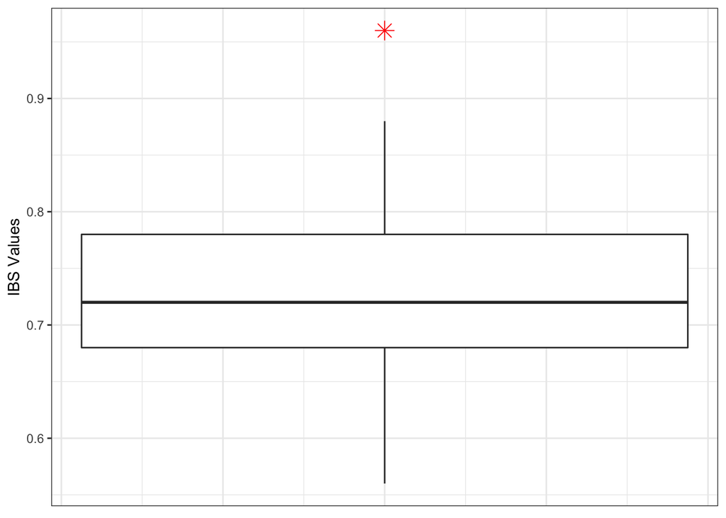

```r
# boxplot result
ibs_long %>%
  ggplot() +
  geom_boxplot(aes(y = ibsdist),
               outlier.colour = "red", outlier.shape=8,
               outlier.size=4) +
  ylab("IBS Values") +
  theme_bw() +
  theme(axis.text.x = element_blank(),
        axis.ticks.x = element_blank())
```

**Conceptual Question:** Describe the distribution. Is this what you expected?

## 4.2 Identity by Descent

In this section, we will use two different “aglorithms” to calculate IBD. The first will be a maximum likelihood estimator that calculates the amount of “inbreeding” which approximates IBD (see Verity et al. 2020 for a mathematical description). Next, we will use a hidden Markov model from the R-package `hmmIBDR`, which is a wrapper for the original `hmmIBD` algorithm (for a full mathematical description of `hmmIBD` see [Schaffner & Taylor 2018](https://pubmed.ncbi.nlm.nih.gov/29764422/)).

#### 4.2.0.1 MLE IBD

As above, we will use `MIPAnalyzer` R package to calculate pairwise IBD for all combinations of samples in our simulated data. Please see the code below for ease of running the algorithm. We are then going to similarly tidy the data from “wide” to “long” format.

```r
#......................
# MLE IBD
#......................
ibd <- MIPanalyzer::inbreeding_mle(x = mipvcf,
                                   f = seq(0.01, 0.99, 0.01),
                                   ignore_het = FALSE,
                                   report_progress = FALSE)
# tidy result
diag(ibd$mle) <- 1
colnames(ibd$mle) <- rownames(ibd$mle) <- colnames(vcf@gt)[2:ncol(vcf@gt)]

ibd_mle_long <- broom::tidy(as.dist(t(ibd$mle))) %>%  # note, mipanalyzer returns upper triangle
  magrittr::set_colnames(c("p1", "p2", "malecotf"))
```

#### 4.2.0.2 Explore Results

We always explore our results!

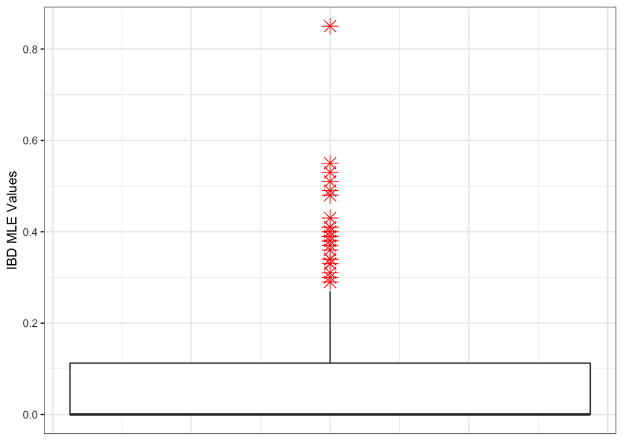

```r
# boxplot result
ibd_mle_long %>%
  ggplot() +
  geom_boxplot(aes(y = malecotf),
               outlier.colour = "red", outlier.shape=8,
               outlier.size=4) +
  ylab("IBD MLE Values") +
  theme_bw() +
  theme(axis.text.x = element_blank(),
        axis.ticks.x = element_blank())
```

**Conceptual Question:** Describe the MLE distribution. Is this what you expected?

#### 4.2.0.3 HMM IBD

As stated above, we will use `hmmIBDR` R package [wrapper](https://github.com/OJWatson/hmmibdr) to calculate pairwise IBD. Please see the code belwo for ease of running the algorithm. Note, we are going to have to do some data munging and writing of input file in order to use the `hmmIBD` [program](https://github.com/glipsnort/hmmIBD).

**Caveat**: The `hmmIBD` algorithm assumes that all samples are monoclonal. As a result, it does not accept heterozygote calls natively. As a user, we have two options: (1) to set those heterozygote calls to missing (a conservative approach), or (2) make a strong assumption about what a heterozygote call means (an aggressive approach). Here, I have forced the samples to be monoclonal by estimating their within-sample allele frequencies and rounding to the nearest variant.

```r
#......................
# hmmIBD setup
#......................
# File of genotype data
ad <- vcfR::extract.gt(vcf, element = "AD")
dp <- vcfR::extract.gt(vcf, element = "DP", as.numeric = T)
altad <- vcfR::masplit(ad, record = 2, sort = F)
wsaf <- altad/dp
colnames(wsaf) <- colnames(vcf@gt)[2:ncol(vcf@gt)]
gt <- dplyr::bind_cols("chrom" = vcfR::getCHROM(vcf), "pos" = vcfR::getPOS(vcf), wsaf)
gtmat <- gt %>%
  tidyr::pivot_longer(., cols = !c("chrom", "pos")) %>%
  dplyr::mutate(chrom = 1,
                gthmm = round(value, 0)) %>%
  dplyr::select(-c("value")) %>%
  tidyr::pivot_wider(data = ., names_from = "name", values_from = "gthmm")
readr::write_tsv(x = gtmat, file = "data/gt_matrix_for_hmmIBD.txt",
                 col_names = T)

# File of allele frequencies for the sample population. Format: tab-delimited, no header, one variant per row. Line format: <chromosome (int)> <position (bp, int)> <allele 1 freq> <all 2 freq> [<all 3 freq>] ... The genotype and frequency files must contain exactly the same variants, in the same order. If no file is supplied, allele frequencies are calculated from the input data file.
altafvec <- rowMeans(wsaf, na.rm = T)
afmat <- dplyr::bind_cols("chrom" = vcfR::getCHROM(vcf),
                          "pos" = vcfR::getPOS(vcf),
                          1-altafvec, altafvec) %>%
  dplyr::mutate(chrom = 1)
readr::write_tsv(afmat, file = "data/af_matrix_for_hmmIBD.txt", col_names = F)

#......................
# hmmIBD run
#......................
tf <- tempfile(pattern = "output_simdat")
out <- hmmibdr::hmm_ibd(input_file = "data/gt_matrix_for_hmmIBD.txt",
                        allele_freqs =  "data/af_matrix_for_hmmIBD.txt",
                        output_file = tf)
```

```
## Maximum fit iterations allowed: 5
## Minimum marker spacing (bp): 5
## Minimum informative markers: 10
## Pairs accepted with discordance in range (0.00%, 100.00%)
## Genotyping error rate: 0.10%
## Input file: data/gt_matrix_for_hmmIBD.txt
## Frequency files: data/af_matrix_for_hmmIBD.txt and none
## pop1 nsample: 25 used: 25 Expected pairs: 300
## Variants skipped for spacing: 6
## 44 variants used,    0 with >2 alleles
## sample pairs analyzed (filtered for discordance and informative markers): 280
```

```r
# hmmIBD tidy
ibd_hmm_long <- tibble::tibble(
  p1 = out$fract$sample1,
  p2 = out$fract$sample2,
  hmm = out$fract$fract_sites_IBD)
```

#### 4.2.0.4 Explore Results

Again!

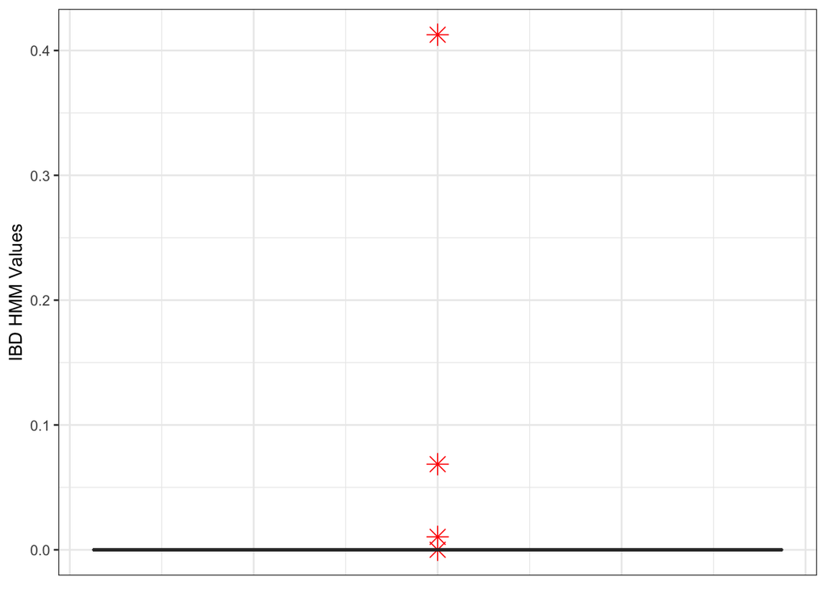

```r
# boxplot result
ibd_hmm_long %>%
  ggplot() +
  geom_boxplot(aes(y = hmm),
               outlier.colour = "red", outlier.shape=8,
               outlier.size=4) +
  ylab("IBD HMM Values") +
  theme_bw() +
  theme(axis.text.x = element_blank(),
        axis.ticks.x = element_blank())
```

**Conceptual Question:** Describe the HMM distribution. Is this what you expected?

#### 4.2.0.5 Contrast MLE vs HMM

Make a plot comparing the MLE IBD vs the HMM IBD results.

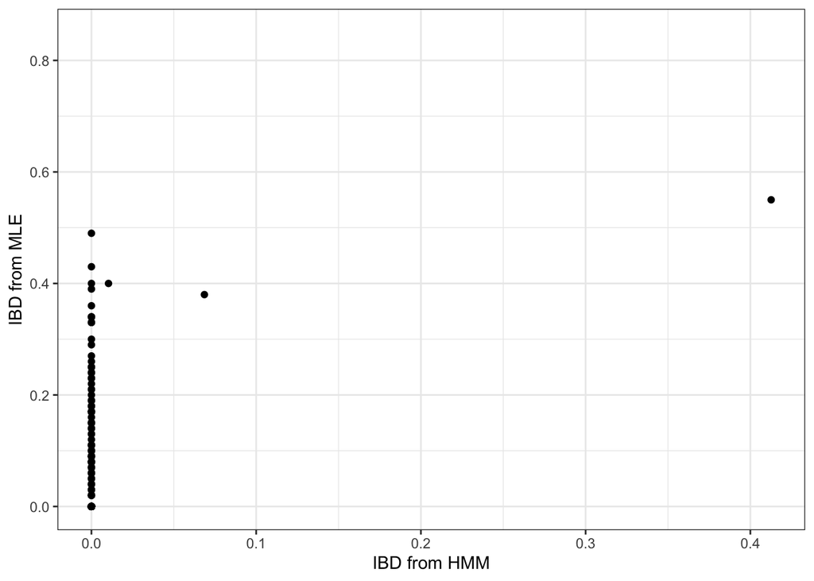

```r
dplyr::left_join(ibd_mle_long, ibd_hmm_long, by = c("p1", "p2")) %>%
  ggplot() +
  geom_point(aes(x = hmm, y = malecotf)) +
  theme_bw() +
  labs(x = "IBD from HMM", y = "IBD from MLE")
```

**Conceptual Question:** Why would these two results differ? Are there any differing assumptions made in the models?  
**Example Answer:** Remember that `hmmIBD` assumes that samples are monoclonal. Therefore, heterozygote calls will break down IBD blocks rapidly under our simple “force” to monoclonal assumption.

### 4.2.1 Summary/Check-In

At this point, you should have created three result objects:  
+ *ibs_long*  
+ *ibd_mle_long*  
+ *ibd_hmm_long*  
If you are having computational trouble or time is a limiting factor, please see the `results/` directory, where you will be able to read in the results.

# 5 Applied IBD

In this section, we will focus on the utility of IBS and IBD for realistic applications related to control and elimination efforts. For this section, we will focus on the MLE-IBD estimates (vs HMM-IBD estimates).

## 5.1 IBS vs IBD

Compare IBS and IBD in a scatterplot.

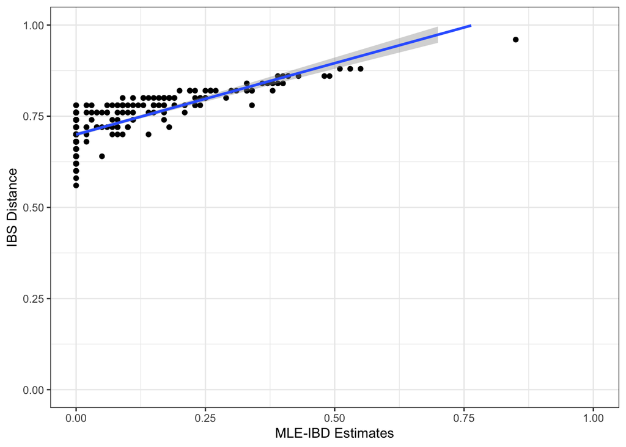

```r
dplyr::left_join(ibs_long, ibd_mle_long, by = c("p1", "p2")) %>%
  ggplot() +
  geom_point(aes(x = malecotf, y = ibsdist)) +
  geom_smooth(aes(x = malecotf, y = ibsdist), method = "lm") +
  xlim(c(0,1)) + ylim(c(0,1)) +
  labs(x = "MLE-IBD Estimates", y = "IBS Distance") +
  theme_bw()
```

**Conceptual Question:** How do the estimates of IBS and IBD differ. What is the smallest value for IBS versus IBD? Why may these be different?  
**Answer:** IBS is affected by the population allele frequencies in a population and can overestimate relatedness when alleles are fixed in a population due to reasons other than inheritance (i.e. IBD = 0, IBS > 0.5, seen on the left-hand side of the plot). Fixation of alleles is particularly common in small populations due to genetic drift (as was the case in this simulation) or due to selection. As a result, although high values of IBS likely indicate high levels of relatedness, lower values of IBS are more difficult to interpret.

## 5.2 IBD Distribution

Now, let’s look at the distribution of our IBD estimates. In particular, we will focus in on the “tail” of the distribution (*i.e.* high values).

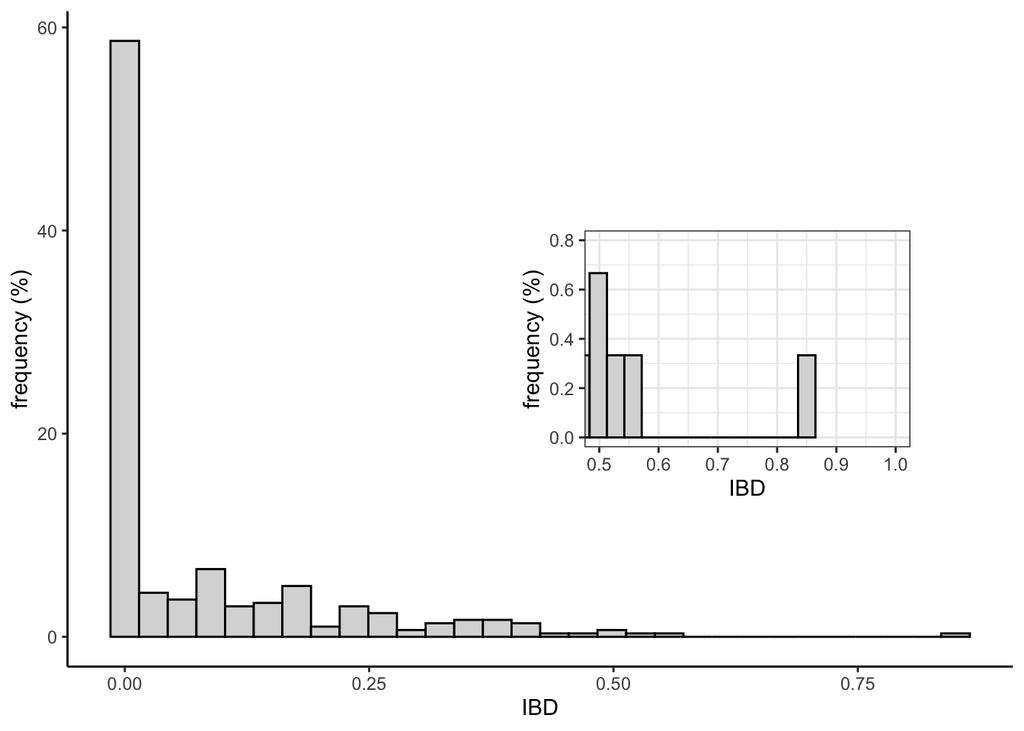

```r
mainplot <- ibd_mle_long %>%
  ggplot() +
  geom_histogram(aes(x=malecotf, y = (..count../sum(..count..))*100),
                 color = "#000000", fill = "#d9d9d9") +
  xlab("IBD") + ylab("frequency (%)") +
  theme_classic()

insetplot <- ibd_mle_long %>%
  ggplot() +
  geom_histogram(aes(x=malecotf, y = (..count../sum(..count..))*100),
                 color = "#000000", fill = "#d9d9d9") +
  xlab("IBD") + ylab("frequency (%)") +
  theme_classic() +
  coord_cartesian(xlim = c(0.5,1), ylim = c(0,0.8)) +
  theme_bw() +
  theme(panel.background = element_rect(fill = "transparent"),
        plot.background = element_rect(fill = "transparent"))
# cowplot
cowplot::ggdraw() +
  cowplot::draw_plot(mainplot, x = 0, y = 0, width = 1, height = 1, scale = 1) +
  cowplot::draw_plot(insetplot, x = 0.5, y= 0.3, width = 0.4, height = 0.4)
```

**Conceptual Question:** How would you describe this distribution? Would you expect this many unrelated samples? What about the proportion of highly related pairs in the tail of the distribution?

## 5.3 Transmission Intensity

As we have seen from the recombination review at the beginning of the practical, as the number of recombination events increases, we expect for IBD due to decrease. As a result, in areas with higher transmission intensity, here modeled through differences in COI, we can expect for IBD to be less.

### 5.3.1 Within-Deme IBD vs COI

By grouping samples together by their home demes, we can estimate the amount of inbreeding within a deme, or the within-deme IBD. Read in the `data/metadata.RDS` file and calculate the mean IBD by deme to get the within-deme IBD. Then plot the within-deme IBD versus simulated mean COI in that deme.

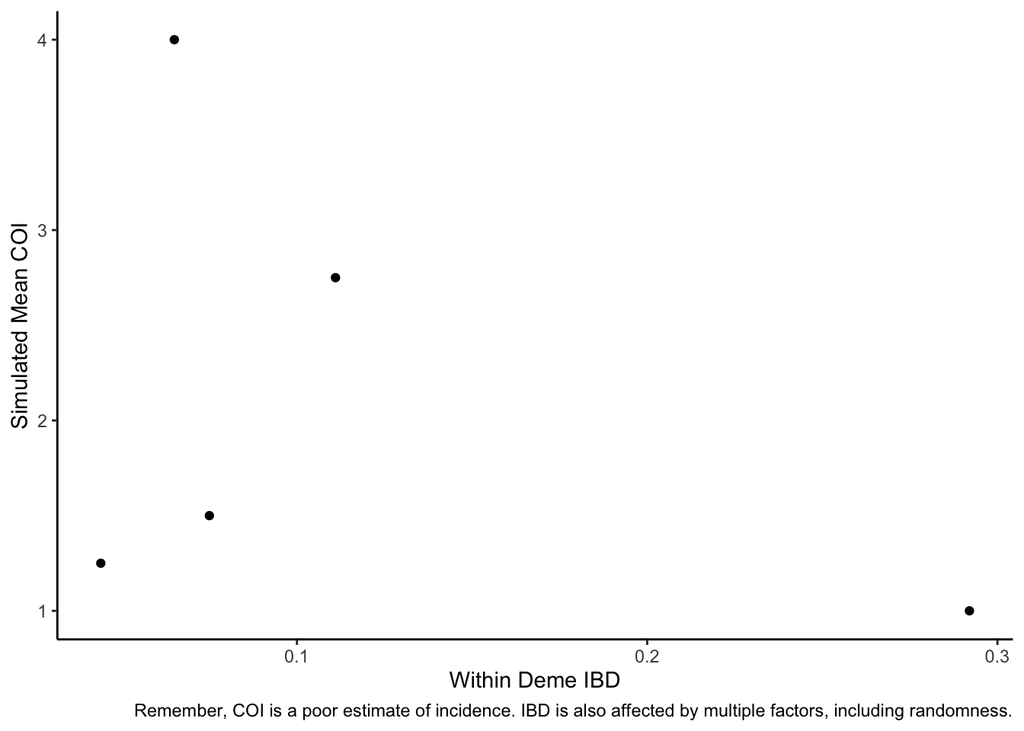

```r
mtdt <- readRDS("data/metadata.RDS")

#......................
# data munging
#......................
mtdt_x <- mtdt %>%
  dplyr::rename(p1 = smpl)
mtdt_y <- mtdt %>%
  dplyr::rename(p2 = smpl)
ibd_mle_long_mtdt <- dplyr::left_join(ibd_mle_long, mtdt_x, by = "p1") %>%
  dplyr::left_join(., mtdt_y, by = "p2") %>%
  rename_with(., ~gsub(".x", "_p1", .x, fixed = T)) %>%
  rename_with(., ~gsub(".y", "_p2", .x, fixed = T))
#......................
# plot within IBD
#......................
ibd_mle_long_mtdt %>%
  dplyr::filter(deme_p1 == deme_p2) %>%
  dplyr::group_by(deme_p1) %>%
  dplyr::summarise(
    withinIBD = mean(malecotf),
    meanCOI = mean(coimeans_p1)) %>%
  ggplot() +
  geom_point(aes(x = withinIBD, y = meanCOI)) +
  labs(x = "Within Deme IBD", y = "Simulated Mean COI",
       caption = "Remember, COI is a poor estimate of incidence. IBD is also affected by multiple factors, including randomness.") +
  theme_classic()
```

**Conceptual Question:** Is there a correlation here between mean COI and within deme IBD?  
**Answer:** No, but the lowest COI was associated with the greatest within deme IBD.

## 5.4 Isolation by Distance

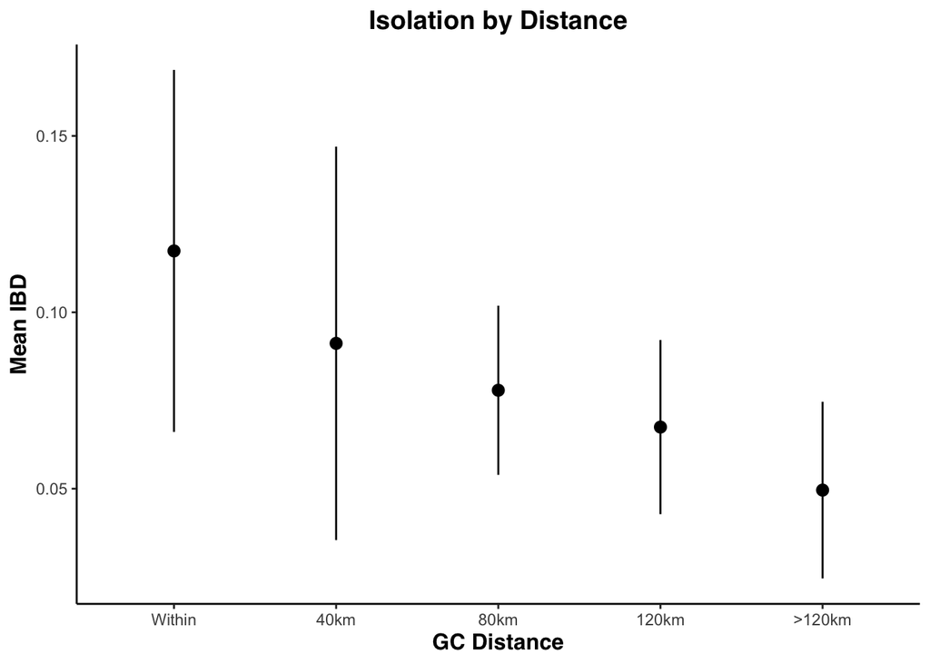

```r
gcdist <- readRDS("data/deme_gc_dist.RDS")
ibd_mle_long_mtdt_dist <- dplyr::left_join(ibd_mle_long_mtdt, gcdist, by = c("deme_p1", "deme_p2")) %>%
  dplyr::mutate(distance = ifelse(is.na(distance), 0, distance))
ibd_mle_long_mtdt_dist$distance_cat <- cut(x = c(ibd_mle_long_mtdt_dist$distance),
                                           breaks = c(0, 1e-26,
                                                      seq(40, 120, by = 40),
                                                      Inf),
                                           right = F, #
                                           labels = c("Within", "40km", "80km", "120km", ">120km"))


ibd_mle_long_mtdt_dist %>%
  dplyr::group_by(distance_cat) %>%
  dplyr::summarise(
    n = n(),
    meanIBD = mean(malecotf),
    sdIBD = sd(malecotf),
    seIBD = sdIBD/sqrt(n),
    U95CI = meanIBD + 1.96 * seIBD,
    L95CI = meanIBD - 1.96 * seIBD) %>%
  ggplot() +
  geom_pointrange(aes(x = distance_cat, y = meanIBD, ymin = L95CI, ymax = U95CI)) +
  scale_size(range = c(0, 1)) +
  labs(y = "Mean IBD", x = "GC Distance", title = "Isolation by Distance") +
  theme_classic() +
  theme(plot.title = element_text(family = "Helvetica", face = "bold", hjust = 0.5, size = 14),
        axis.title = element_text(family = "Helvetica", face = "bold", hjust = 0.5, size = 12))
```

**Conceptual Question:** How would you describe this relationship? Does it make sense?

### 5.4.1 Network Analysis

We can also use networks to determine the connectivity of our paired samples. Networks helps us visualize connections that we may not expect and are a useful tool for exploratory data analysis. Additionally, we can use [community detection algorithms](https://towardsdatascience.com/community-detection-algorithms-9bd8951e7dae) to explore which samples may “cluster” together based on relatedness. One way to conceptualize community detection algorithms is to consider that networks measure “popularity” and that samples that are “cliques” should cluster together. Alternatively, a sample may be “friends” with everyone and becomes very central or important to the network. These distinctions may be helpful to determine which demes are particularly connected and may be contributing to sink-source dynamics (see [Wesolowksi *et al.* 2018](https://pubmed.ncbi.nlm.nih.gov/30333020/) for further information on sink-source dynamics).

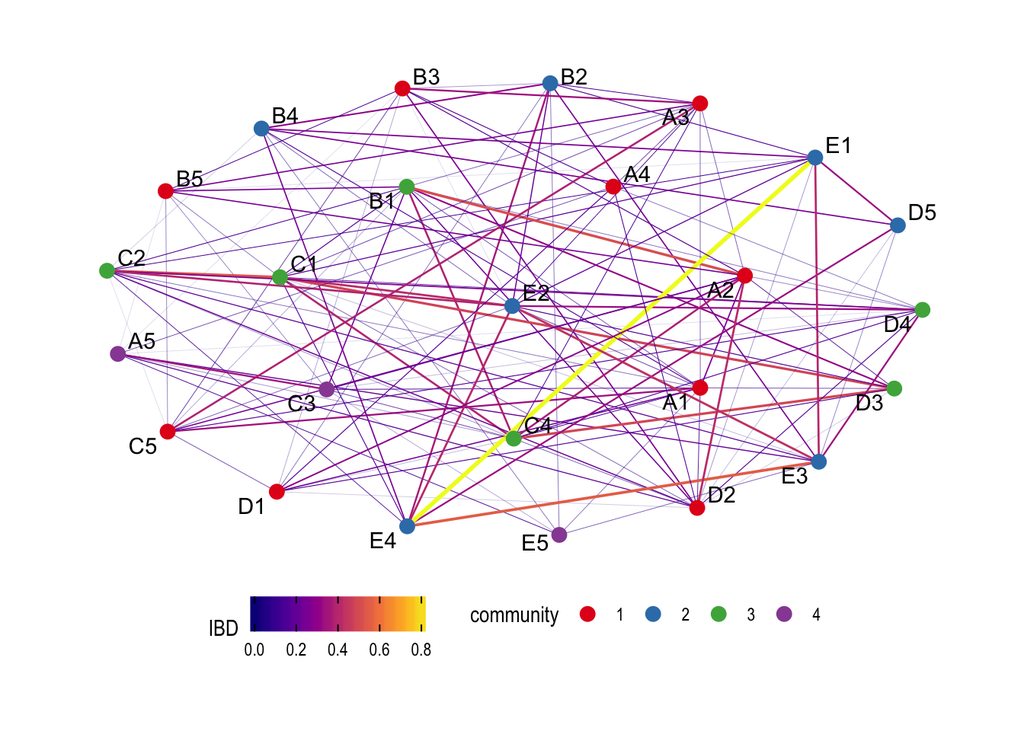

```r
adj_graph <- ibd_mle_long %>%
  tidygraph::as_tbl_graph(., directed = F)

ibd_mle_long %>%
  tidygraph::as_tbl_graph(., directed = F) %>%
  dplyr::mutate(community = as.factor(tidygraph::group_louvain(weights = malecotf))) %>%
  tidygraph::activate("edges") %>%
  ggraph::ggraph(layout = 'kk') +
  ggraph::geom_edge_link(aes(width = malecotf,
                             color = malecotf)) +
  ggraph::geom_node_point(aes(color = community),
                          size = 3) +
  ggraph::scale_edge_width_continuous(range = c(0, 1), guide = "none") +
  ggraph::geom_node_text(aes(label = name), repel = T) +
  ggraph::scale_edge_color_viridis("IBD", values = c(0,1), option = "plasma") +
  scale_color_brewer(palette = "Set1") +
  ggraph::theme_graph() +
  theme(legend.position = "bottom")
```

**Conceptual Question:** What do you notice about the above network? Are there any isolated cliques? Are there any very “popular” samples?

## 5.5 High Related Pairs

Here, we will subset to highly related pairs, defined as pairs that are at least meiotic siblings (*i.e.* share half of their genome). We will then map these between deme connections to determine if there is evidence of genetic sharing between demes. You can find the map at the following location: `data/sim_map_sf.RDS`. Use the `sf` package to make the plot below.

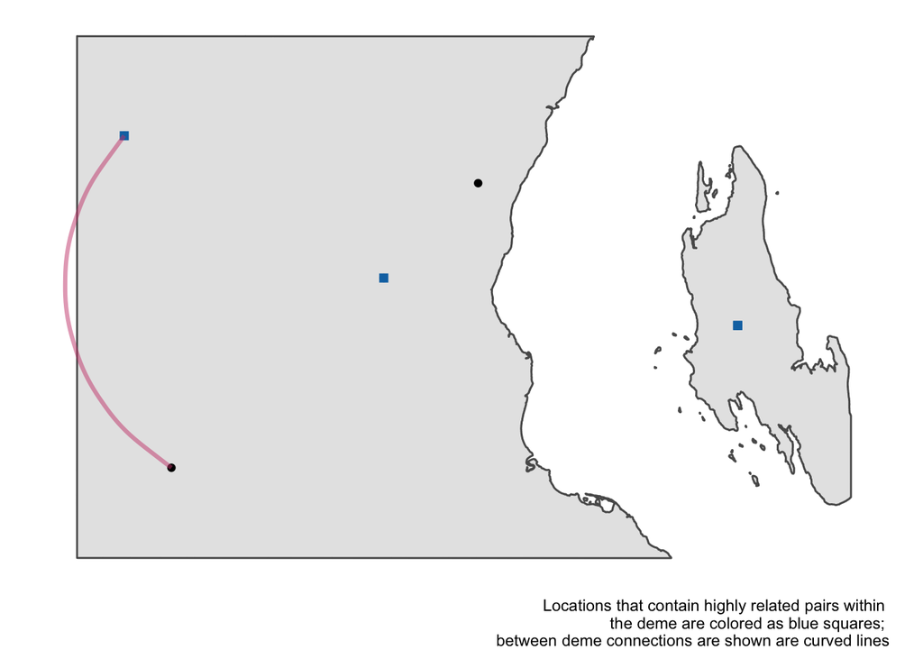

```r
# read in map base
simmap <- readRDS("data/sim_map_sf.RDS")
mtdtclst <- mtdt %>%
  dplyr::select(c("deme", "longnum", "latnum")) %>%
  dplyr::filter(!duplicated(.))

# perform subset
highpairs <- ibd_mle_long_mtdt %>%
  dplyr::filter(malecotf >= 0.5)
# find within
withinpairs <- highpairs %>%
  dplyr::mutate(win = deme_p1 == deme_p2)
# find btwn up
highbtwnpairs <- highpairs %>%
  dplyr::filter(deme_p1 != deme_p2)

# make plot
ggplot() +
  geom_sf(data = simmap) +
  geom_point(data = mtdtclst, aes(x = longnum, y = latnum),
             show.legend = F) +
  geom_point(data = withinpairs, aes(x = longnum_p1, y = latnum_p1),
             show.legend = F,
             color = "#0C73B2", shape = 15, size = 2) +
  geom_curve(data = highbtwnpairs,
             alpha = 0.5, size = 1.1,
             aes(x = longnum_p1, y = latnum_p1,
                 xend = longnum_p2, yend = latnum_p2,
                 color = malecotf), show.legend = F) +
  scale_color_viridis_c("Pairwise IBD", option="plasma", direction = 1, values = c(0,1)) +
  labs(caption = "Locations that contain highly related pairs within \n the deme are colored as blue squares; \n between deme connections are shown are curved lines") +
  theme_minimal() +
  theme(panel.grid = element_blank(),
        axis.title = element_blank(),
        axis.text = element_blank(),
        axis.ticks = element_blank())
```

**Conceptual Question:** What can highly related pairs tell you? How do they relate to transmission events? Can you use them to estimate genetic corridors or evidence fo gene flow? Do you think there is active transmission between the mainland and island (see original study hypothesis)?

## 5.6 Self Exploration

You have reached the end of the practical. If time permits, you can explore this Shiny app which will allow you to simulate new genetic data and explore how different parameters (COI, migration, population size) affect IBD.

# 6 Advanced/Extra

This section contains advanced material and additional resources for interested participants.

## 6.1 IBS & Polyclonality

Recently, [Tessema & Wesolowski et al. 2021](https://elifesciences.org/articles/43510) defined IBS for polyclonal samples as the proportion of sites that are identical divided by the potential alleles in all strains. Specifically, this can be expressed as for a pair of samples, $X$ and $Y$, the total number of shared alleles $S_{i}$ across the two samples divided by all alleles at that locus for sample $X$, $X_{i}$ and all alleles at that locus for sample $Y$, $Y_{i}$. This can be summed across all loci to produce an overall estimate of IBS.

$$IBS= \frac{1}{n} \sum_{i=1}^{n}
\frac{S_{i}} {X_{i}Y_{i}}$$

## 6.2 IBD & Polyclonality

As was described in the case of `hmmIBD`, polyclonality greatly complicates IBD estimates and is an active area of research. Recent solutions include considering the malaria genome as diploid, which allows for heterozygous alleles: [`isoRelate`](https://github.com/bahlolab/isoRelate) or phasing polyclonal infections and estimating IBD from the resultant haplotypes: [deploidIBD](https://github.com/DEploid-dev/DEploid). This is an active area of research and remains a challenge within the malaria genomic epidemiology field.

## 6.3 Manipulating VCFs

If time permits, check out [`vcftools`](https://vcftools.github.io/index.html). Try and subset our VCF to sample “A1” from the command line. Now try and subset to a single loci.  
Manipulating VCFs on the command line is a key skill for a bioinformatician!

## 6.4 HMMs

Hidden Markov models (HMMs) are a common statistical approach in population genetics, and for detecting IBD. For further reading, see [Rabiner 1989](https://web.mit.edu/6.435/www/Rabiner89.pdf).

## 6.5 Coalescent Model

Coalescent theory is one of the central pillars of population genetics and provides a framework for how loci (genes, individuals, etc.) have been derived from a common ancestor backwards in time, classically using the assumptions of the Wright-Fisher model. One of the main assumptions of the coalescence, is that loci are independent and that no recombination is occurring between loci. To relax this assumption, we must consider the coalescence with recombination. In this framework, a single coalescent tree is no longer representative of the genome (*NB*: genomes are now combination of genes on intervals [0, L) ; [L, L_{+1}], see [Griffiths & Marjoram 1996](http://lamastex.org/recomb/ima.pdf) for further details). As a result, each loci in the gene interval has a marginal tree due recombination resulting in different genealogical histories of loci. The collection of these trees with respect to recombination breakpoints among loci in the gene interval is termed the Ancestral Recombination Graph (ARG). Relatedness is considered as the time to most recent common ancestor (TMRCA) for a given loci and gives a more refined estimate of relatedness versus the binary distinction of whether or not a specific segment of the genome is IBD.

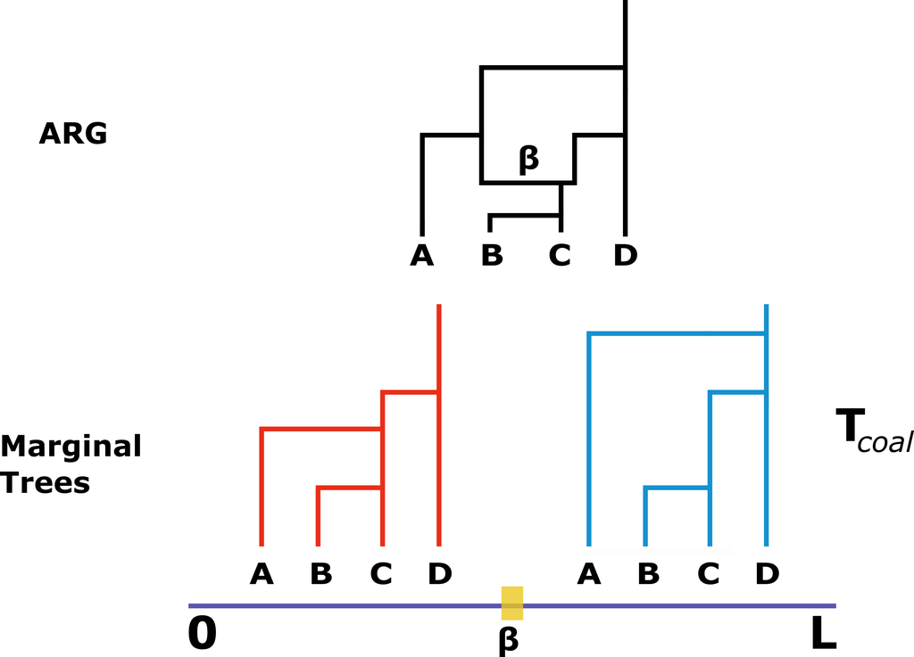

For further reading, please refer to the following sources:  
[Wakeley: Coalescent Theory: An Introduction](https://www.amazon.com/Coalescent-Theory-Introduction-John-Wakeley/dp/0974707759)  
[Li & Stephens: 2003 PSMC](https://www.ncbi.nlm.nih.gov/pmc/articles/PMC1462870/)  
[Li & Durbin: 2011 PSMC](https://pubmed.ncbi.nlm.nih.gov/21753753/)